# Explore_bikeshare_data

### Explore Bike Share Data

For this project, your goal is to ask and answer three questions about the available bikeshare data from Washington, Chicago, and New York. This notebook can be submitted directly through the workspace when you are confident in your results.

You will be graded against the project [Rubric](https://review.udacity.com/#!/rubrics/2508/view) by a mentor after you have submitted. To get you started, you can use the template below, but feel free to be creative in your solutions!

```r
ny = read.csv('new_york_city.csv')
wash = read.csv('washington.csv')
chi = read.csv('chicago.csv')
```

```r
head(ny)
```

| X | Start.Time | End.Time | Trip.Duration | Start.Station | End.Station | User.Type | Gender | Birth.Year |
| --- | --- | --- | --- | --- | --- | --- | --- | --- |
| 5688089 | 2017-06-11 14:55:05 | 2017-06-11 15:08:21 | 795 | Suffolk St & Stanton St | W Broadway & Spring St | Subscriber | Male | 1998 |
| 4096714 | 2017-05-11 15:30:11 | 2017-05-11 15:41:43 | 692 | Lexington Ave & E 63 St | 1 Ave & E 78 St | Subscriber | Male | 1981 |
| 2173887 | 2017-03-29 13:26:26 | 2017-03-29 13:48:31 | 1325 | 1 Pl & Clinton St | Henry St & Degraw St | Subscriber | Male | 1987 |
| 3945638 | 2017-05-08 19:47:18 | 2017-05-08 19:59:01 | 703 | Barrow St & Hudson St | W 20 St & 8 Ave | Subscriber | Female | 1986 |
| 6208972 | 2017-06-21 07:49:16 | 2017-06-21 07:54:46 | 329 | 1 Ave & E 44 St | E 53 St & 3 Ave | Subscriber | Male | 1992 |
| 1285652 | 2017-02-22 18:55:24 | 2017-02-22 19:12:03 | 998 | State St & Smith St | Bond St & Fulton St | Subscriber | Male | 1986 |

```r
head(wash)
```

| X | Start.Time | End.Time | Trip.Duration | Start.Station | End.Station | User.Type |
| --- | --- | --- | --- | --- | --- | --- |
| 1621326 | 2017-06-21 08:36:34 | 2017-06-21 08:44:43 | 489.066 | 14th & Belmont St NW | 15th & K St NW | Subscriber |
| 482740 | 2017-03-11 10:40:00 | 2017-03-11 10:46:00 | 402.549 | Yuma St & Tenley Circle NW | Connecticut Ave & Yuma St NW | Subscriber |
| 1330037 | 2017-05-30 01:02:59 | 2017-05-30 01:13:37 | 637.251 | 17th St & Massachusetts Ave NW | 5th & K St NW | Subscriber |
| 665458 | 2017-04-02 07:48:35 | 2017-04-02 08:19:03 | 1827.341 | Constitution Ave & 2nd St NW/DOL | M St & Pennsylvania Ave NW | Customer |
| 1481135 | 2017-06-10 08:36:28 | 2017-06-10 09:02:17 | 1549.427 | Henry Bacon Dr & Lincoln Memorial Circle NW | Maine Ave & 7th St SW | Subscriber |
| 1148202 | 2017-05-14 07:18:18 | 2017-05-14 07:24:56 | 398.000 | 1st & K St SE | Eastern Market Metro / Pennsylvania Ave & 7th St SE | Subscriber |

```r
dim(wash)
```

1. 89051

2. 7

```r
head(chi)
```

| X | Start.Time | End.Time | Trip.Duration | Start.Station | End.Station | User.Type | Gender | Birth.Year |
| --- | --- | --- | --- | --- | --- | --- | --- | --- |
| 1423854 | 2017-06-23 15:09:32 | 2017-06-23 15:14:53 | 321 | Wood St & Hubbard St | Damen Ave & Chicago Ave | Subscriber | Male | 1992 |
| 955915 | 2017-05-25 18:19:03 | 2017-05-25 18:45:53 | 1610 | Theater on the Lake | Sheffield Ave & Waveland Ave | Subscriber | Female | 1992 |
| 9031 | 2017-01-04 08:27:49 | 2017-01-04 08:34:45 | 416 | May St & Taylor St | Wood St & Taylor St | Subscriber | Male | 1981 |
| 304487 | 2017-03-06 13:49:38 | 2017-03-06 13:55:28 | 350 | Christiana Ave & Lawrence Ave | St. Louis Ave & Balmoral Ave | Subscriber | Male | 1986 |
| 45207 | 2017-01-17 14:53:07 | 2017-01-17 15:02:01 | 534 | Clark St & Randolph St | Desplaines St & Jackson Blvd | Subscriber | Male | 1975 |
| 1473887 | 2017-06-26 09:01:20 | 2017-06-26 09:11:06 | 586 | Clinton St & Washington Blvd | Canal St & Taylor St | Subscriber | Male | 1990 |

```r
# Add "city" column to wash data frame
wash$City <- "washington"
wash$Gender <- "N/A"
wash$Birth.Year <- "N/A"

# Add "city" column to chi data frame
chi$City <- "chicago"

# Add "city" column to ny data frame
ny$City <- "new york"

# Create an empty data frame to store the combined results
combined_df <- data.frame()

# Combine the data frames while reseeding the X column
combined_df <- rbind(
  transform(wash, X = seq_along(X)),
  transform(chi, X = seq_along(X)),
  transform(ny, X = seq_along(X))
)

# Reset row names of the combined data frame
rownames(combined_df) <- NULL

# View the combined data frame
head(combined_df)
```

| X | Start.Time | End.Time | Trip.Duration | Start.Station | End.Station | User.Type | City | Gender | Birth.Year |
| --- | --- | --- | --- | --- | --- | --- | --- | --- | --- |
| 1 | 2017-06-21 08:36:34 | 2017-06-21 08:44:43 | 489.066 | 14th & Belmont St NW | 15th & K St NW | Subscriber | washington | N/A | N/A |
| 2 | 2017-03-11 10:40:00 | 2017-03-11 10:46:00 | 402.549 | Yuma St & Tenley Circle NW | Connecticut Ave & Yuma St NW | Subscriber | washington | N/A | N/A |
| 3 | 2017-05-30 01:02:59 | 2017-05-30 01:13:37 | 637.251 | 17th St & Massachusetts Ave NW | 5th & K St NW | Subscriber | washington | N/A | N/A |
| 4 | 2017-04-02 07:48:35 | 2017-04-02 08:19:03 | 1827.341 | Constitution Ave & 2nd St NW/DOL | M St & Pennsylvania Ave NW | Customer | washington | N/A | N/A |
| 5 | 2017-06-10 08:36:28 | 2017-06-10 09:02:17 | 1549.427 | Henry Bacon Dr & Lincoln Memorial Circle NW | Maine Ave & 7th St SW | Subscriber | washington | N/A | N/A |
| 6 | 2017-05-14 07:18:18 | 2017-05-14 07:24:56 | 398.000 | 1st & K St SE | Eastern Market Metro / Pennsylvania Ave & 7th St SE | Subscriber | washington | N/A | N/A |

```r
dim(combined_df)
```

1. 152451

2. 10

```r
# Extract the Day of Week from the "Start_Date" column
combined_df$Day.Week <- weekdays(as.Date(combined_df$Start.Time))

# Extract the month from the "Start_Date" column
combined_df$Month <- format(as.Date(combined_df$Start.Time), "%b")

# Extract the month from the "Start_Date" column
combined_df$Year <- format(as.Date(combined_df$Start.Time), "%Y")

# Convert the "Start.Time" column to POSIXct format with the correct format
combined_df$Start.Time <- as.POSIXct(combined_df$Start.Time, format = "%Y-%m-%d %H:%M:%S")

# Convert the "Start.Time" column to POSIXct format with the correct format
combined_df$End.Time <- as.POSIXct(combined_df$End.Time, format = "%Y-%m-%d %H:%M:%S")

# Extract the hour of the day from the "Start.Time" column
combined_df$Start.Hour <- format(combined_df$Start.Time, "%H")

# Extract the hour of the day from the "Start.Time" column
combined_df$End.Hour <- format(combined_df$End.Time, "%H")
```

```r
head(combined_df)
```

| X | Start.Time | End.Time | Trip.Duration | Start.Station | End.Station | User.Type | City | Gender | Birth.Year | Day.Week | Month | Year | Start.Hour | End.Hour |
| --- | --- | --- | --- | --- | --- | --- | --- | --- | --- | --- | --- | --- | --- | --- |
| 1 | 2017-06-21 08:36:34 | 2017-06-21 08:44:43 | 489.066 | 14th & Belmont St NW | 15th & K St NW | Subscriber | washington | N/A | N/A | Wednesday | Jun | 2017 | 08 | 08 |
| 2 | 2017-03-11 10:40:00 | 2017-03-11 10:46:00 | 402.549 | Yuma St & Tenley Circle NW | Connecticut Ave & Yuma St NW | Subscriber | washington | N/A | N/A | Saturday | Mar | 2017 | 10 | 10 |
| 3 | 2017-05-30 01:02:59 | 2017-05-30 01:13:37 | 637.251 | 17th St & Massachusetts Ave NW | 5th & K St NW | Subscriber | washington | N/A | N/A | Tuesday | May | 2017 | 01 | 01 |
| 4 | 2017-04-02 07:48:35 | 2017-04-02 08:19:03 | 1827.341 | Constitution Ave & 2nd St NW/DOL | M St & Pennsylvania Ave NW | Customer | washington | N/A | N/A | Sunday | Apr | 2017 | 07 | 08 |
| 5 | 2017-06-10 08:36:28 | 2017-06-10 09:02:17 | 1549.427 | Henry Bacon Dr & Lincoln Memorial Circle NW | Maine Ave & 7th St SW | Subscriber | washington | N/A | N/A | Saturday | Jun | 2017 | 08 | 09 |
| 6 | 2017-05-14 07:18:18 | 2017-05-14 07:24:56 | 398.000 | 1st & K St SE | Eastern Market Metro / Pennsylvania Ave & 7th St SE | Subscriber | washington | N/A | N/A | Sunday | May | 2017 | 07 | 07 |

### 1. Most Popular Hour of Day

> Determining the most popular hour of travel is crucial for Motivate. By analyzing the hour of travel data, we can identify the peak demand period and optimize resource allocation, bike availability, and rider experience. Insights gained from exploring temporal trends will help align operations, maintenance, and marketing strategies to cater to peak usage times, ensuring a seamless bike sharing experience that meets riders' preferences and travel habits.

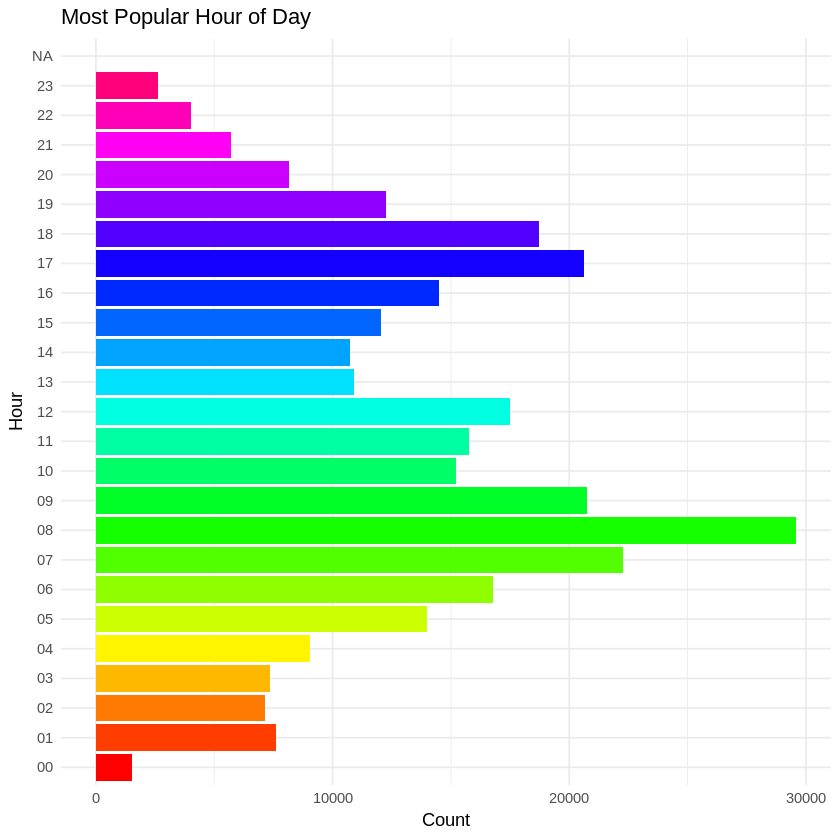

```r
library(ggplot2)
library(dplyr)

# Create a temporary data frame with combined Start.Hour and End.Hour records
temp_df <- bind_rows(
  data.frame(Hour = combined_df$Start.Hour),
  data.frame(Hour = combined_df$End.Hour)
)

# Create a bar plot for month distribution
ggplot(temp_df, aes(x = Hour, fill = Hour)) +
  geom_bar() +
  labs(x = "Hour", y = "Count", title = "Most Popular Hour of Day") +
  scale_fill_manual(values = rainbow(length(unique(temp_df$Hour)))) +
  theme_minimal() +
  theme(legend.position = "none") +
  coord_flip()
```

#### Result Summary

> Based on the analysis of the dataset, it was found that the most popular hour of travel for Motivate is 8am, with a count of around 30,000 trips. This hour experiences a substantial surge in bike usage and represents the peak period of activity. In comparison, the next popular hour, 7am, has a count approximately 7,500 trips lower than the peak at 8am. The data reveals a clear pattern of high demand during the morning rush hour, indicating a strong preference for bike sharing as a convenient mode of transportation during this time.

### 2. Average Trip Duration (in minutes) by City

> Analyzing average trip durations by city is crucial for Motivate. It helps optimize operations, understand user behavior, and tailor services to meet the unique needs of riders in each city. This data-driven analysis empowers Motivate to enhance customer experience and improve the overall efficiency of their bike sharing service.

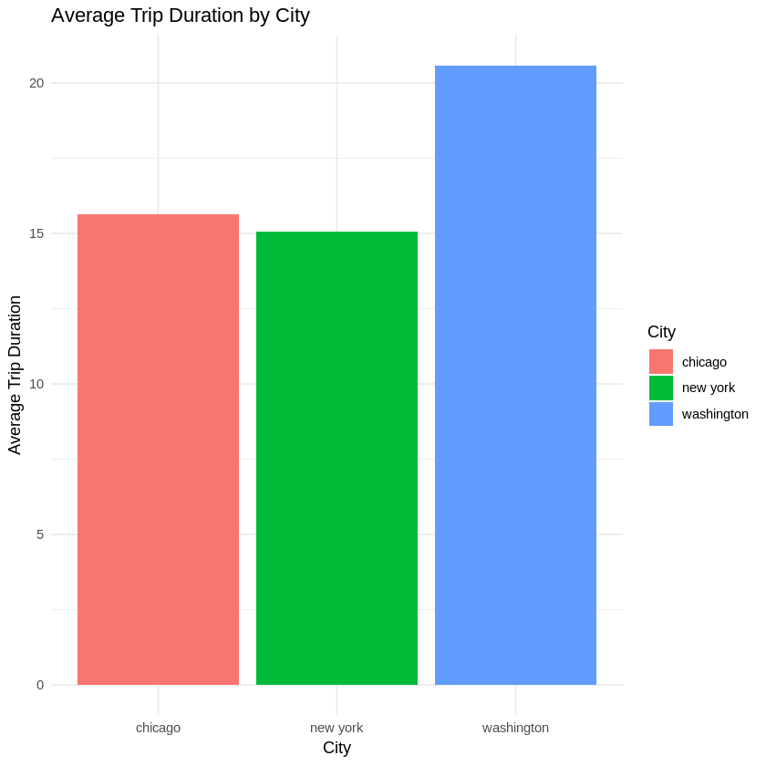

```r
avg_trip_duration <- mean(combined_df$Trip.Duration)

# Calculate the average trip duration for each city group
avg_trip_duration <- aggregate(Trip.Duration/60 ~ City, data = combined_df, FUN = mean)

# Create a bar plot for average trip duration by city group
ggplot(avg_trip_duration, aes(x = City, y = `Trip.Duration/60`, fill = City)) +
  geom_bar(stat = "identity") +
  labs(x = "City", y = "Average Trip Duration", title = "Average Trip Duration by City") +
  theme_minimal()
```

#### Result Summary

> The analysis of the dataset revealed the average trip duration (in minutes) for each city serviced by Motivate. The average trip durations came out to be:
> - Chicago & New York ~ 15 min
> - Washington ~ 20 min

> Overall, we can assume a few things potentiall from these results. (1) Users in washington are more active & (2) Users in washington have farther distances to cover

### 3. Average Trip Duration (in minutes) by Gender

> Understanding the average trip duration by gender is essential potential address potential disparities or preferences that may exist. By examining the differences in trip durations between genders, Motivate can gain valuable insights into usage patterns and tailor their services to better meet the needs of all riders.

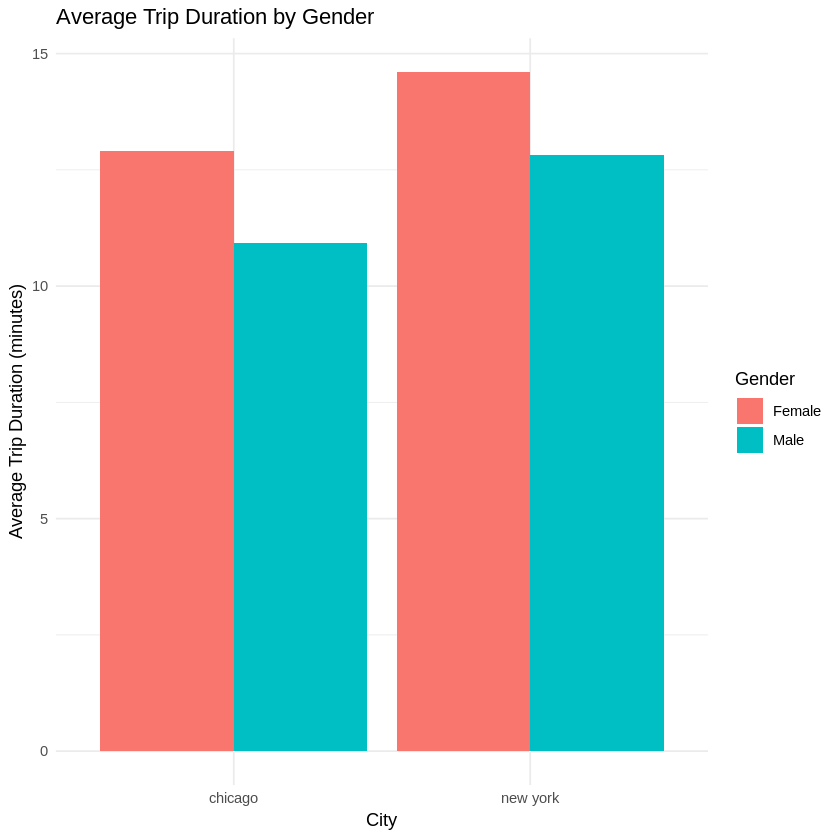

```r
# Filter the data for New York and Chicago cities and remove empty or NA values
filtered_df <- combined_df[combined_df$City %in% c("new york", "chicago"), ]

# Calculate the average trip duration in minutes for each gender in each city
avg_trip_duration <- aggregate(Trip.Duration/60 ~ City + Gender, data = filtered_df, FUN = mean)

# Filter the data to show only Female and Male genders
avg_trip_duration <- avg_trip_duration[avg_trip_duration$Gender %in% c("Female", "Male"), ]

# Create a grouped bar plot for average trip duration by city and gender
ggplot(avg_trip_duration, aes(x = City, y = `Trip.Duration/60`, fill = Gender)) +
  geom_bar(stat = "identity", position = "dodge") +
  labs(x = "City", y = "Average Trip Duration (minutes)", title = "Average Trip Duration by Gender") +
  theme_minimal()
```

#### Result Summary

```r
system('python -m nbconvert Explore_bikeshare_data.ipynb')
```